# Day7

matplotlib 数据分析展示 2

```python
import warnings
warnings.filterwarnings('ignore')
```

```python
import numpy as np
import pandas as pd
import matplotlib.pyplot as plt
```

```python
plt.rcParams['font.sans-serif']=['SimHei']
plt.rcParams['axes.unicode_minus']=False
```

```python
df=pd.read_excel('movie_data3.xlsx')
```

```python
df[:5]
```

|  | 年代 | 产地 | 名字 | 投票人数 | 类型 | 上映时间 | 时长 | 评分 | 首映地点 | 评分等级 | 热门程度 |
| --- | --- | --- | --- | --- | --- | --- | --- | --- | --- | --- | --- |
| 0 | 1994 | 美国 | 肖申克的救赎 | 692795 | 剧情/犯罪 | 1994-09-10 00:00:00 | 142 | 9.6 | 多伦多电影节 | A | A |
| 1 | 1957 | 美国 | 控方证人 | 42995 | 剧情/悬疑/犯罪 | 1957-12-17 00:00:00 | 116 | 9.5 | 美国 | A | A |
| 2 | 1997 | 意大利 | 美丽人生 | 327855 | 剧情/喜剧/爱情 | 1997-12-20 00:00:00 | 116 | 9.5 | 意大利 | A | A |
| 3 | 1994 | 美国 | 阿甘正传 | 580897 | 剧情/爱情 | 1994-06-23 00:00:00 | 142 | 9.4 | 洛杉矶首映 | A | A |
| 4 | 1993 | 中国大陆 | 霸王别姬 | 478523 | 剧情/爱情/同性 | 1993-01-01 00:00:00 | 171 | 9.4 | 香港 | A | A |

## 双轴图

```python
import matplotlib.mlab as mlab
```

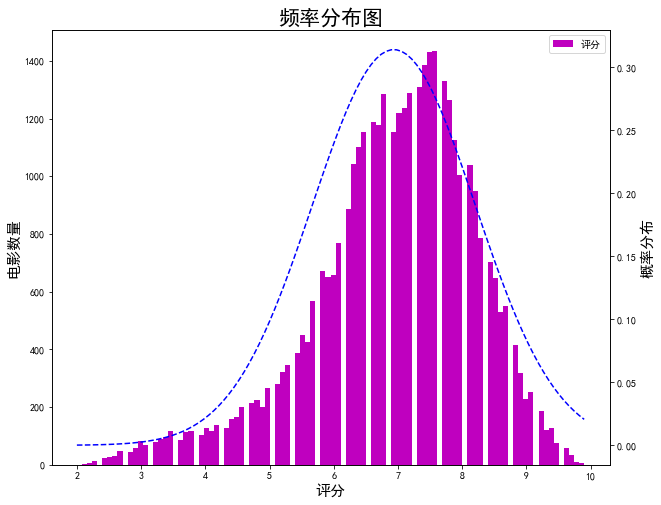

```python
fig=plt.figure(figsize=(10,8))
ax1=fig.add_subplot(111)
n,bins,patches=ax1.hist(df['评分'],bins=100,color='m')

ax1.set_ylabel('电影数量',fontsize=15)
ax1.set_xlabel('评分',fontsize=15)
ax1.set_title('频率分布图',fontsize=21)
plt.legend()
# 曲线拟合:
# y=mlab.normpdf(bins,mu,sigma)
y=mlab.normpdf(bins,df['评分'].mean(),df['评分'].std())
ax2=ax1.twinx() # 用同一个 x 轴，双 y 轴
ax2.plot(bins,y,'b--')

ax2.set_ylabel('概率分布',fontsize=15)

plt.show()
```

## 散点图

用两组数据构成多个坐标点，考察坐标点的分布，判断两变量之间是否存在某种关联或总结坐标点的分布模式。散点图将序列显示为一组点。值由点在图表中的位置表示。类别由图表中的不同标记表示。散点图通常用于比较跨类别的聚合数据。

**根据电影时长和电影评分绘制散点图**

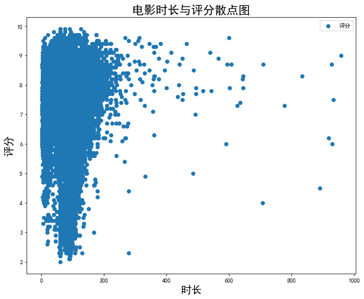

```python
x=df['时长']
y=df['评分']

plt.figure(figsize=(10,8))
plt.scatter(x,y)
plt.legend()
plt.title('电影时长与评分散点图',fontsize=20)
plt.xlabel('时长',fontsize=18)
plt.ylabel('评分',fontsize=18)

plt.show()
```

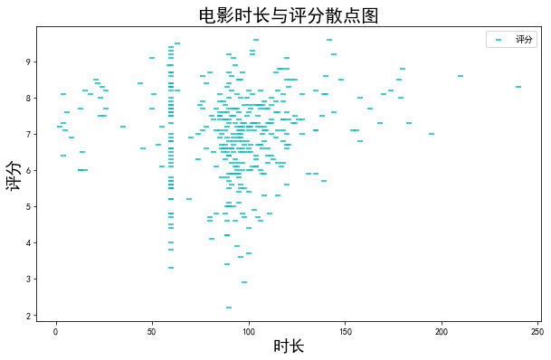

```python
# 提取原有数据的 1% 进行绘图
x=df['时长'][::100]
y=df['评分'][::100]

plt.figure(figsize=(10,6))
plt.scatter(x,y,color='c',marker='_')
plt.legend()
plt.title('电影时长与评分散点图',fontsize=20)
plt.xlabel('时长',fontsize=18)
plt.ylabel('评分',fontsize=18)

plt.show()
```

由于我们数据量过大，所以画出来的图非常冗杂

可以发现，大多数电影时长还是集中在100附近，评分大多在7分左右

### marker 属性

#### 设置散点的形状

[figure not shown]

## 箱型图

箱型图（Box Plot）又称为盒须图、盒式图或箱线图，是一种用作显示一组数据分散情况资料的统计图。因形状如箱子而得名，在各种领域也经常被使用，常见于品质管理。它主要用于反映原始数据分布特征，还可以进行多组数据分布特征的比较。箱线图的绘制方法是：先找出一组数据的中位数、两个四分位数、上下边缘线；然后，连接两个四分位数画出箱子；再将上下边缘线与箱子连接，中位数在箱子中间。

[figure not shown]

### 一般计算过程

1. 计算上四分位数（Q3），中位数，下四分位数（Q1）
2. 计算上四分位数和下四分位数之间的差值，即四分位数差（IQR，interquartile range）Q3-Q1
3. 绘制箱线图的上下范围，上限为上四分位数，下限为下四分位数。在箱子内部中位数的位置绘制横线
4. 大于上四分位数 1.5 倍四分位数差的值，或者小于下四分位数 1.5 倍四分位数差的值，划为异常值（outliers）
5. 异常值之外，最靠近上边缘和下边缘的两个值处，划横线，作为箱线图的触须
6. 极端异常值，即超出四分位数差 3 倍距离的异常值，用实心点表示；较为温和的异常值，即处于 1.5 倍 ~ 3 倍四分位数差之间的异常值，用空心点表示
7. 为箱线图添加名称、轴等

### 参数详解

plt.boxplot(...)

**绘制美国电影评分箱线图**

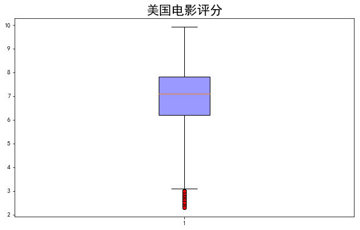

```python
data=df[df.产地=='美国']['评分']
plt.figure(figsize=(10,6))
plt.boxplot(data,whis=2,flierprops={'marker':'o','markerfacecolor':'r','color':'k'},
           patch_artist=True,boxprops={'color':'k','facecolor':'#9999ff'})
plt.title('美国电影评分',fontsize=21)
plt.show()
```

**多组数据箱线图**

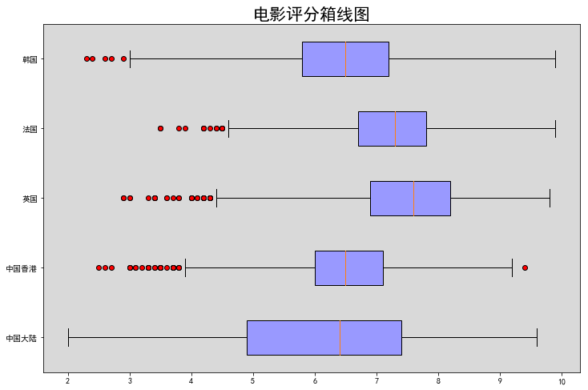

```python
data1=df[df.产地=='中国大陆']['评分']
data2=df[df.产地=='中国香港']['评分']
data3=df[df.产地=='英国']['评分']
data4=df[df.产地=='法国']['评分']
data5=df[df.产地=='韩国']['评分']

plt.figure(figsize=(12,8))
plt.boxplot([data1,data2,data3,data4,data5],labels=['中国大陆','中国香港','英国','法国','韩国'],
           whis=2,flierprops={'marker':'o','markerfacecolor':'r','color':'k'},
           patch_artist=True,boxprops={'color':'k','facecolor':'#9999ff'},
           vert=False) # vert 可以横置箱线图

ax=plt.gca() # 获取当前坐标系
ax.patch.set_facecolor('gray')
ax.patch.set_alpha(0.3)

plt.title('电影评分箱线图',fontsize=21)
plt.show()
```

## 相关系数矩阵图——热力图

```python
data=df[['投票人数','评分','时长']]
data[:5]
```

|  | 投票人数 | 评分 | 时长 |
| --- | --- | --- | --- |
| 0 | 692795 | 9.6 | 142 |
| 1 | 42995 | 9.5 | 116 |
| 2 | 327855 | 9.5 | 116 |
| 3 | 580897 | 9.4 | 142 |
| 4 | 478523 | 9.4 | 171 |

Pandas 本身也封装了画图函数，我们可以画出各个属性之间的散点图，对角线是分布图

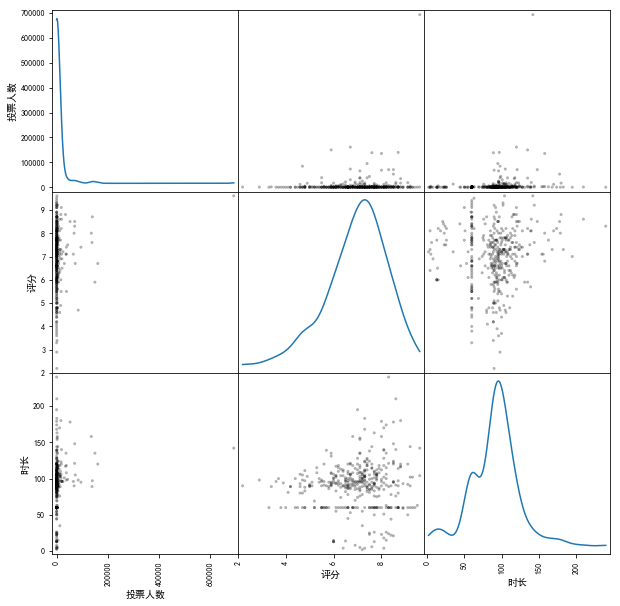

```python
%pylab inline
result=pd.scatter_matrix(data[::100],diagonal='kde',color='k',alpha=0.3,figsize=(10,10))
```

### seaborn

seaborn 是一个精简的 Python 库，可以创建具有统计意义的图表，能够理解 Pandas 的DataFrame 类型

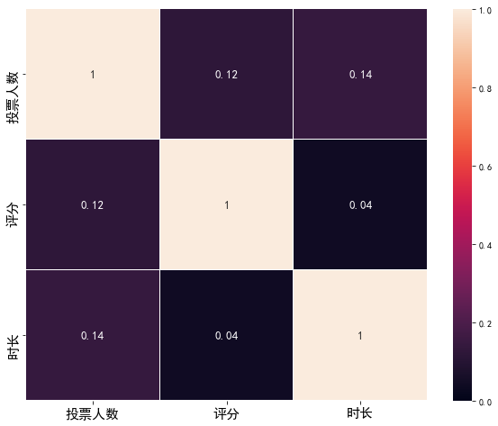

```python
import seaborn as sns

corr=data.corr()
corr=abs(corr)

fig=plt.figure(figsize=(10,8))
ax=fig.add_subplot(figsize=(10,8))

ax=sns.heatmap(corr,vmax=1,vmin=0,annot=True,annot_kws={'size':13,'weight':'bold'},linewidths=0.05)

plt.xticks(fontsize=15)
plt.yticks(fontsize=15)

plt.show()
```

#### 参数详解

seaborn.heatmap(...)

##### 热力图输入数据参数

- data：矩阵数据集，可以是 numpy 的数组（array），也可以是 pandas 的 DataFrame。如果是 DataFrame，则 df 的 index/column 信息会分别对应到 heatmap 的 columns 和 rows，即 pt.index 是热力图的行标，pt.columns 是热力图的列标

##### 热力图矩阵块注释参数

- annot：（annotate的缩写）默认 False，如果是 True，在热力图每个方格写入数据；如果是矩阵，在热力图每个方格写入该矩阵对应位置数据
- fmt：字符串格式代码，矩阵上标识数字的数据格式，比如保留小数点后几位数字
- anno_kws：默认 False，如果是 True，设置热力图矩阵上数字的大小、颜色、字体等（matplotlib 包 text 类下的字体设置）

##### 热力图矩阵块之间间隔及间隔线参数

- linewidths：定义热力图里“表示两两特征关系的矩阵小块”之间的间隔大小
- linecolor：切分热力图上每个矩阵小块的线的颜色，默认 white

##### 热力图颜色刻度条参数

- cbar：是否在热力图侧边绘制颜色刻度条，默认值是 True
- cbar_kws：热力图侧边绘制颜色刻度条时，相关字体设置，默认是 None
- cbar_ax：热力图侧边绘制颜色刻度条时，刻度条的位置，默认是 None

##### square：设置热力图矩阵小块的形状，默认 False

- xticklabels,yticklabels：分别控制每列、每行标签名的输出，默认 auto；如果是 True，则以 DataFrame 的列名作为标签名；若是 False，则不添加行标签名；若是列表，则标签名改为列表中给的内容；若是整数 K，则在图上每隔 K 个标签进行一次标注